# IODS course project

Agata Dominowska

# Introduction to Open Data Science

**Autumn 2017**

**Link to my GitHub repository**  
https://github.com/aadomino/IODS-project

*Our era of data - larger than ever and complex like chaos - requires several skills from statisticians and other data scientists. We must discover the patterns hidden behind numbers in matrices and arrays.*

We are not afraid of

- coding,
- recoding,
- programming,
- modelling.

We want to

1. visualize,
2. analyze,
3. interpret:
   - understand
   - communicate

> These are the core themes of Open Data Science and this course.

# Regression and model validation

*The objective of this week was learning, performing and interpreting the results of regression analysis. This part includes code, intrepretations and explanations of the results obtained with blood, sweat and tears.*

## 1. Reading and exploring the data

The data used in this part comes from an international survey of approaches to learning - see more [on this page.](http://www.helsinki.fi/~kvehkala/JYTmooc/JYTOPKYS3-meta.txt)).

You can find the pre-processed data here: [GitHub data repository.](https://github.com/adomino/IODS-project/data)

The dataset, *learning2014*, consists of 166 observations and 7 variables - these are the dimensions of the data. You can see it here:

```r
learning2014 <- read.table("C:/Users/P8Z77-V/Documents/learning2014.csv", header = TRUE, sep = "\t")
dim(learning2014)
```

```
## [1] 166   7
```

It is also possible to observe the data structure of the data frame:

```r
str(learning2014)
```

```
## 'data.frame':    166 obs. of  7 variables:
##  $ gender  : Factor w/ 2 levels "F","M": 1 2 1 2 2 1 2 1 2 1 ...
##  $ age     : int  53 55 49 53 49 38 50 37 37 42 ...
##  $ attitude: int  37 31 25 35 37 38 35 29 38 21 ...
##  $ deep    : num  3.58 2.92 3.5 3.5 3.67 ...
##  $ surf    : num  2.58 3.17 2.25 2.25 2.83 ...
##  $ stra    : num  3.38 2.75 3.62 3.12 3.62 ...
##  $ points  : int  25 12 24 10 22 21 21 31 24 26 ...
```

The variables occurring in the data are *gender, age, attitude, deep, stra, surf*, and *points*.

These variables are used to categorise the answers of students from the survey. The questions pertained to the students’ assessment of their deep-, strategic-, and surface learning, and the data was also collected on their age, gender, and attitude towards statistics.

The dataset does not contain the students who received 0 points from the final exam. These results have been filtered out:

```r
learning2014 <- dplyr::filter(learning2014, points > 0)
```

## 2. Taking a more detailed look at the data

#### Summary of the variables

The summary of the data includes a lot of information on all the variables. There are minimum, maximum, median and mean values of each category, and the first and the third quintiles of the data.

```r
summary(learning2014)
```

```
##  gender       age           attitude          deep            surf
##  F:110   Min.   :17.00   Min.   :14.00   Min.   :1.583   Min.   :1.583
##  M: 56   1st Qu.:21.00   1st Qu.:26.00   1st Qu.:3.333   1st Qu.:2.417
##          Median :22.00   Median :32.00   Median :3.667   Median :2.833
##          Mean   :25.51   Mean   :31.43   Mean   :3.680   Mean   :2.787
##          3rd Qu.:27.00   3rd Qu.:37.00   3rd Qu.:4.083   3rd Qu.:3.167
##          Max.   :55.00   Max.   :50.00   Max.   :4.917   Max.   :4.333
##       stra           points
##  Min.   :1.250   Min.   : 7.00
##  1st Qu.:2.625   1st Qu.:19.00
##  Median :3.188   Median :23.00
##  Mean   :3.121   Mean   :22.72
##  3rd Qu.:3.625   3rd Qu.:27.75
##  Max.   :5.000   Max.   :33.00
```

An overview of this dataset produces a few interesting observations. We can clearly see that there are more female respondents than male ones, and the *age* variable represents typical age distribution of university students. Most of them are in their twenties, with a few outliers with the ages from 17 to 55. The *attitude* variable shows that the survey participants approach statistics with a slightly more positive than negative attitude. Deep learning is favoured more than strategic or surface learning (deep, stra and surf variables). The final exam results range from 7 to 33.

#### A graphical overview

With a graphical plot we can actually visualise the variables and the relationships between them.

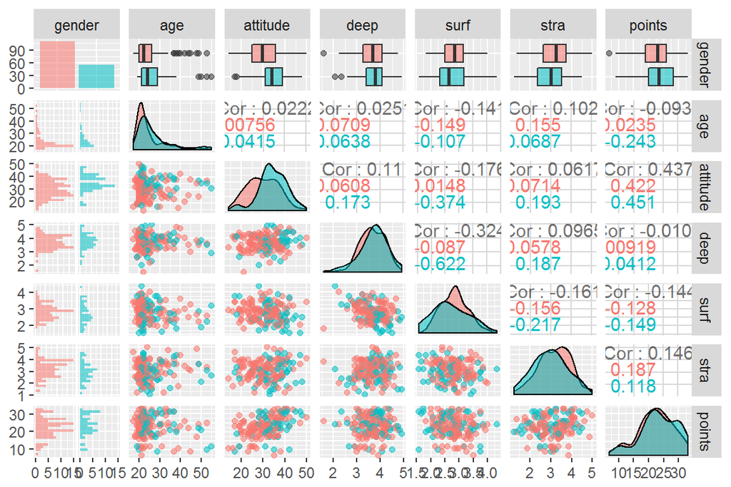

```r
# Access the GGally and ggplot2 libraries.
library(GGally)
library(ggplot2)

# Read a plot matrix with ggpairs() into a variable p0. Draw.
p0 <- ggpairs(learning2014, mapping = aes(col = gender, alpha = 0.3), lower = list(combo = wrap("facethist", bins = 20)))
p0
```

It is a complex plot. One thing that stands out is that there is some positive correlation between exam points received by the students and their attitude towards statistics, but the correlation between exam points and other variables is generally weak. In general, the correlations between variables in our dataset are not strong.

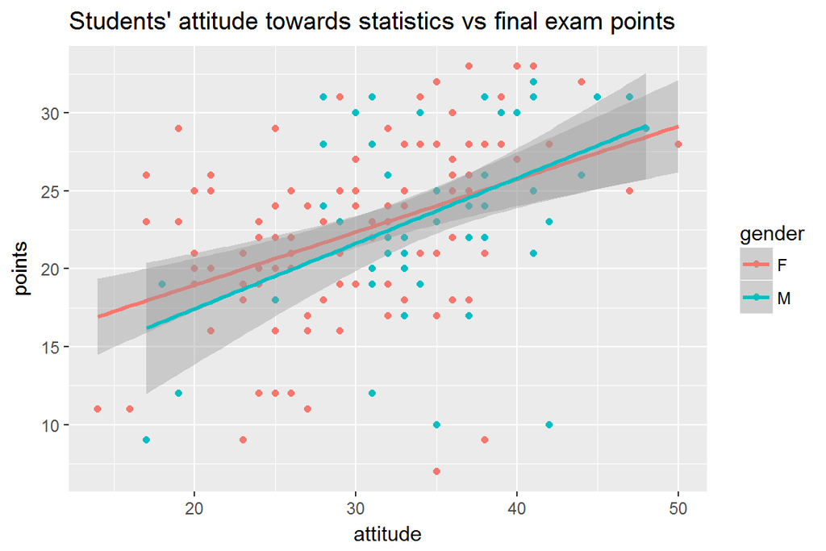

```r
# Access the ggplot2 library.
library(ggplot2)

# Draw the plot (p1) with our data. Define the mapping. Define the visualization type (dots) and smoothing. Add the plot title.
p1 <- ggplot(learning2014, aes(x = attitude, y = points, col = gender)) + geom_point() + geom_smooth(method = "lm") + ggtitle("Students' attitude towards statistics vs final exam points")
p1
```

## 3. Choosing and fitting a regression model

In this part we will choose and fit a suitable regression model, which will explain the data in more detail - we want to find out which factors influence the amount of exam points received. *Points* is the target (dependent) variable. The previous section shows that *attitude*, *stra* and *surf* correlate most strongly with *points*. They will be our explanatory variables in this model, the summary of which is printed out below:

```r
# Fit a regression model (m0) with multiple explanatory variables: attitude, stra, surf. Print a summary of the model.
m0 <- lm(points ~ attitude + stra + surf, data = learning2014)
summary(m0)
```

```
##
## Call:
## lm(formula = points ~ attitude + stra + surf, data = learning2014)
##
## Residuals:
##      Min       1Q   Median       3Q      Max
## -17.1550  -3.4346   0.5156   3.6401  10.8952
##
## Coefficients:
##             Estimate Std. Error t value Pr(>|t|)
## (Intercept) 11.01711    3.68375   2.991  0.00322 **
## attitude     0.33952    0.05741   5.913 1.93e-08 ***
## stra         0.85313    0.54159   1.575  0.11716
## surf        -0.58607    0.80138  -0.731  0.46563
## ---
## Signif. codes:  0 '***' 0.001 '**' 0.01 '*' 0.05 '.' 0.1 ' ' 1
##
## Residual standard error: 5.296 on 162 degrees of freedom
## Multiple R-squared:  0.2074, Adjusted R-squared:  0.1927
## F-statistic: 14.13 on 3 and 162 DF,  p-value: 3.156e-08
```

The results show the variables used in the model.

Residuals are assumed to be normally distributed with zero mean and constant variance. The median is indeed close to zero and the residuals seem to follow normal distribution.

```r
# Create a regression model m1 with only attitude. Print a summary of the model.
m1 <- lm(points ~ attitude, data = learning2014)
summary(m1)
```

```
##
## Call:
## lm(formula = points ~ attitude, data = learning2014)
##
## Residuals:
##      Min       1Q   Median       3Q      Max
## -16.9763  -3.2119   0.4339   4.1534  10.6645
##
## Coefficients:
##             Estimate Std. Error t value Pr(>|t|)
## (Intercept) 11.63715    1.83035   6.358 1.95e-09 ***
## attitude     0.35255    0.05674   6.214 4.12e-09 ***
## ---
## Signif. codes:  0 '***' 0.001 '**' 0.01 '*' 0.05 '.' 0.1 ' ' 1
##
## Residual standard error: 5.32 on 164 degrees of freedom
## Multiple R-squared:  0.1906, Adjusted R-squared:  0.1856
## F-statistic: 38.61 on 1 and 164 DF,  p-value: 4.119e-09
```

## 4. Interpreting the results

The multiple R-squared value evaluates how much of the changes (variance) of the target variable is explained by the model. The rest of the variance is explained by some other factors that are not included. It could be understood as a goodness of fit measure.

The multiple R-squared is higher in the first model, even though the explanatory variables were shown to be statistically not significant and were subsequently dropped. The value increases when any variables are added to the model, irrespective of their significance.